# Capstone_Cyclistic

Meryem Mimir

2022-11-30

## Capstone Project ~ Cyclistic

This is an R Markdown document for my Capstone Project of Google Data Analytics Training on Coursera. In this document you will find all the steps taken on the way of the project and scripts of codes on these steps.

### Preparing Data

#### Downloading Data

Necessary packages and their libraries were installed

```r
install.packages("tidyverse", repos = "http://cran.us.r-project.org")
```

```r
install.packages("ggplot2", repos = "http://cran.us.r-project.org")
install.packages("dplyr", repos = "http://cran.us.r-project.org")
install.packages("readxl", repos = "http://cran.us.r-project.org")
install.packages('rlang',repos = "http://cran.us.r-project.org")
library("tidyverse")
library("ggplot2")
library("dplyr")
library("readxl")
library("rlang")
```

#### Binding Data

All the dataframes combined into a new dataframe:

```r
data <- rbind(Trips_202210,
              Trips_202209,
              Trips_202208,
              Trips_202207,
              Trips_202206,
              Trips_202205,
              Trips_202204,
              Trips_202203,
              Trips_202202,
              Trips_202201,
              Trips_202112,
              Trips_202111)
```

#### Checking Data

1. Data was checked if there is any NA entries in any vector

```r
#is there a null entry in any vector

sum(is.na(data$ride_id))
```

```
## [1] 0
```

```r
sum(is.na(data$rideable_type))
```

```
## [1] 0
```

```r
sum(is.na(data$started_at))
```

```
## [1] 0
```

```r
sum(is.na(data$ended_at))
```

```
## [1] 0
```

```r
sum(is.na(data$start_station_name))
```

```
## [1] 0
```

```r
sum(is.na(data$start_station_id))
```

```
## [1] 0
```

```r
sum(is.na(data$end_station_name))
```

```
## [1] 0
```

```r
sum(is.na(data$end_station_id))
```

```
## [1] 0
```

```r
sum(is.na(data$start_lat))
```

```
## [1] 0
```

```r
sum(is.na(data$start_lng))
```

```
## [1] 0
```

```r
sum(is.na(data$end_lat))#5835 null values
```

```
## [1] 5835
```

```r
sum(is.na(data$end_lng))#5835 null values
```

```
## [1] 5835
```

```r
sum(is.na(data$member_casual))
```

```
## [1] 0
```

2. Data was checked if there is any null entries in any vector

```r
sum(data$ride_id == "")
```

```
## [1] 0
```

```r
sum(data$rideable_type == "")
```

```
## [1] 0
```

```r
sum(data$started_at == "")
```

```
## [1] 0
```

```r
sum(data$ended_at == "")
```

```
## [1] 0
```

```r
sum(data$start_station_name == "")#878177
```

```
## [1] 878177
```

```r
sum(data$start_station_id == "")#878177
```

```
## [1] 878177
```

```r
sum(data$end_station_name == "")#940010
```

```
## [1] 940010
```

```r
sum(data$end_station_id == "")#940010
```

```
## [1] 940010
```

```r
sum(data$start_lat == "")
```

```
## [1] 0
```

```r
sum(data$start_lng == "")
```

```
## [1] 0
```

```r
sum(data$end_lat == "")
```

```
## [1] NA
```

```r
sum(data$end_lng == "")
```

```
## [1] NA
```

```r
sum(data$member_casual == "")
```

```
## [1] 0
```

3. Variables of “member_casual” and “rideable_type” were checked if there are different values other than their parameters

```r
# check the distinct values in membership vector
unique(data$member_casual)
```

```
## [1] "member" "casual"
```

```r
# > unique(data$member_casual)
# [1] "member" "casual"

# check the distinct values in rideable_type vector
unique(data$rideable_type)
```

```
## [1] "classic_bike"  "electric_bike" "docked_bike"
```

```r
#unique(data$rideable_type)
#[1] "classic_bike"  "electric_bike" "docked_bike"
```

#### Preparing Data

1. A new variable was added to the dataframe: Travel time (ride length) of each trip.

```r
#calculate the travel time of each trip

data$started_at_newformat <- as.POSIXct(data$started_at, format="%Y-%m-%d %H:%M:%OS")

data$ended_at_newformat <- as.POSIXct(data$ended_at, format="%Y-%m-%d %H:%M:%OS")

data$ride_length_min <- difftime(data$ended_at_newformat, data$started_at_newformat,units = "mins")
```

2. This new variable was checked if there is any zero or negative entries.

```r
#check if there is any zero and negative data in ride_length vector.

sum(data$ride_length ==0,na.rm=T) #454
```

```
## [1] 454
```

```r
sum(data$ride_length < 0,na.rm=T) #112
```

```
## [1] 112
```

3. A new variable was added to the dataframe : day_of_week. This gives the day information of the starting date of each ride.

```r
#calculate day of week each ride started

data$started_at_date <- as.Date(data$started_at)

data$day_of_week <- weekdays(data$started_at_date)

data$ride_length <- as.numeric(data$ride_length_min)
```

4. 3 new variables were added to the dataframe: Day,month and year infos of the starting date of each ride.

```r
data$month <- format(as.Date(data$started_at_date), "%m")

data$day <- format(as.Date(data$started_at_date), "%d")

data$year <- format(as.Date(data$started_at_date), "%Y")
```

5. A new vector was added to the dataset : Mode_day_of_week

```r
#create a mode function in r

 getmode <- function(x) {
   uniqv <- unique(x)
   uniqv[which.max(tabulate(match(x, uniqv)))]
 }
# calculate mode of day of week

 Mode_day_of_week <- getmode(data$day_of_week)

# Add columns that list the date, month, day, and year of each ride
# This will allow us to aggregate ride data for each month, day, or year ... before completing these operations we could only aggregate at the ride level
```

### Cleaning Data

1. The data was filtered from entries in which start_station_name, start_station_id, end_station_name, end_station_id variables were null

```r
data_clean <-
data%>%
  filter( start_station_name != ""&
          start_station_id != ""&
          end_station_name != ""&
          end_station_id != "")
```

2. The data was filtered from entries in which ride_length variables are null or 0 or negative.

```r
data_clean <-
  data_clean%>%
  drop_na(ride_length) %>%
  filter(ride_length > 0)
```

3. The vectors modified were checked again.

```r
#Checking the vectors modified.

sum(data_clean$ride_length ==0)
```

```
## [1] 0
```

```r
sum(data_clean$ride_length =="")
```

```
## [1] 0
```

```r
sum(is.na(data_clean$ride_length))
```

```
## [1] 0
```

```r
sum(data_clean$start_station_name == "")
```

```
## [1] 0
```

```r
sum(data_clean$start_station_id == "")
```

```
## [1] 0
```

```r
sum(data_clean$end_station_name == "")
```

```
## [1] 0
```

```r
sum(data_clean$end_station_id == "")
```

```
## [1] 0
```

## Descriptive Analysis

After processing the data, a descriptive analysis was done.

1. Average of the travel time of all rides was calculated.

```r
#calculate mean of ride_length_min

Average_travel_time <- mean(data_clean$ride_length) #17.245
```

2. Median of the travel time of all rides was calculated.

```r
#calculate median of ride_length_min

Median_travel_time <- median(data_clean$ride_length)
```

3. Maximum travel time was calculated.

```r
#calculate max of ride_length_min

Max_travel_time <- max(data_clean$ride_length)
```

4. Minimum travel time was calculated.

```r
#calculate min of ride_length_min

Min_travel_time <- min(data_clean$ride_length) # 0.01667
```

5. Summary of the travel time is

```r
summary <- summary(data_clean$ride_length)

   # Min.  1st Qu.   Median     Mean  3rd Qu.     Max.
   #  0.02     6.08    10.67    17.24    19.12 34294.07
```

6. Aggregate functions for members and casuals.

```r
# aggregate functions for members vs casuals

aggregate(data_clean$ride_length ~ data_clean$member_casual, FUN = mean)
```

```
##   data_clean$member_casual data_clean$ride_length
## 1                   casual               24.40240
## 2                   member               12.45523
```

```r
#    data_clean$member_casual data_clean$ride_length
# 1                   casual               24.40240
# 2                   member               12.45523

aggregate(data_clean$ride_length ~ data_clean$member_casual, FUN = min)
```

```
##   data_clean$member_casual data_clean$ride_length
## 1                   casual             0.01666667
## 2                   member             0.01666667
```

```r
#  data_clean$member_casual data_clean$ride_length
# 1                   casual             0.01666667
# 2                   member             0.01666667

aggregate(data_clean$ride_length ~ data_clean$member_casual, FUN = max)
```

```
##   data_clean$member_casual data_clean$ride_length
## 1                   casual              34294.067
## 2                   member               1492.917
```

```r
# data_clean$member_casual data_clean$ride_length
# 1                   casual              34294.067
# 2                   member               1492.917

aggregate(data_clean$ride_length ~ data_clean$member_casual, FUN = median)
```

```
##   data_clean$member_casual data_clean$ride_length
## 1                   casual               14.01667
## 2                   member                9.00000
```

```r
#   data_clean$member_casual data_clean$ride_length
# 1                   casual               14.01667
# 2                   member                9.00000
```

7. Average travel time by each day for members vs casual users was calculated

```r
# average travel time by each day for members vs casual users

aggregate(data_clean$ride_length ~ data_clean$member_casual+data_clean$day_of_week, FUN = mean)
```

```
##    data_clean$member_casual data_clean$day_of_week data_clean$ride_length
## 1                    casual                 Friday               22.68005
## 2                    member                 Friday               12.21149
## 3                    casual                 Monday               25.27924
## 4                    member                 Monday               12.01395
## 5                    casual               Saturday               26.95896
## 6                    member               Saturday               14.03080
## 7                    casual                 Sunday               27.65379
## 8                    member                 Sunday               13.87878
## 9                    casual               Thursday               21.88746
## 10                   member               Thursday               12.01618
## 11                   casual                Tuesday               21.85358
## 12                   member                Tuesday               11.78205
## 13                   casual              Wednesday               21.20156
## 14                   member              Wednesday               11.83696
```

### Visualization

1. This viz shows us the number of rides of each user type

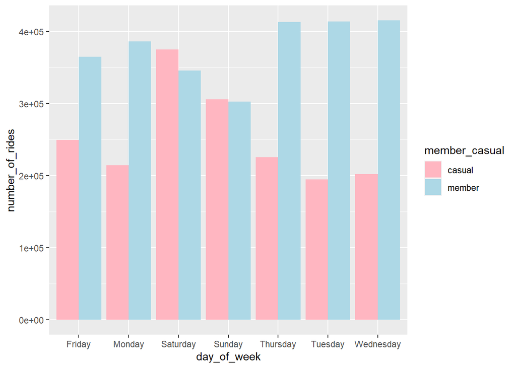

[figure not shown]

number of rides on each day of each user type

```r
data_clean %>%
  group_by(member_casual,day_of_week) %>%  #groups by usertype and weekday
  summarise(number_of_rides = n()                           #calculates the number of rides
  ,average_duration = mean(ride_length)) %>%        # calculates the average duration
  arrange(member_casual, day_of_week)       %>%                         # sorts

  ggplot(aes(x = day_of_week, y = number_of_rides,fill = member_casual)) + #visualize it for number_of_rides
  geom_col(position = "dodge" )+
  scale_fill_manual(values = c(member = "lightblue",casual = "lightpink"))
```

2. This viz shows us the average travel time of each user type

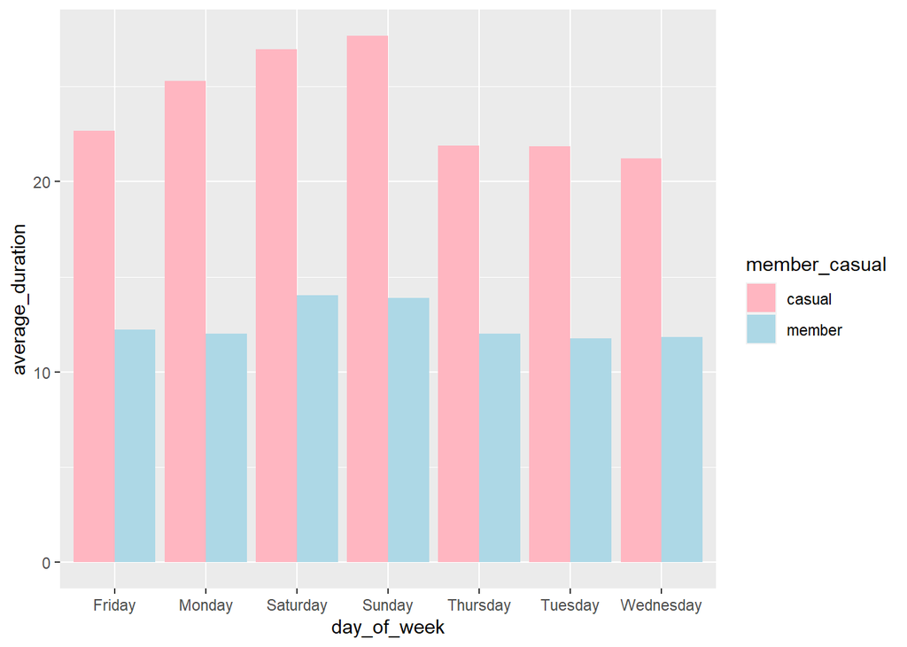

[figure not shown]

average travel time on each day of each user type

```r
data_clean %>%
  group_by(member_casual, day_of_week) %>%  #groups by usertype and weekday
  summarise(number_of_rides = n()                           #calculates the number of rides and average duration
  ,average_duration = mean(ride_length)) %>%        # calculates the average duration
  arrange(member_casual, day_of_week)       %>%                         # sorts

  ggplot(aes(x = day_of_week, y = average_duration, fill = member_casual)) + #visualize it for average_duration
  geom_col(position = "dodge")+
  scale_fill_manual(values = c(member = "lightblue",casual = "lightpink"))
```